# Assignment: Electricity Market Prices

Ozan Barış Baykan

11/11/2020

```r
df <- read_excel("C:/Users/ETR04585/Desktop/ptf-smf.xls")
```

## A Report for Possible Cost-down Suggestion regarding to Energy Budget

### Introduciton and Preprocessing

Electricity Market Prices in September 2020 was analyzed.

If you would like to get data of Electricity Market Prices, please click [here](https://rapor.epias.com.tr/rapor/xhtml/ptfSmfListeleme.xhtml).

MCP is a market-clearing price that is used planned purchasing.

SMP is system marginal price that unplanned purchasing such as energy deficit, energy surplus.

Let’s look at the data set.

```r
glimpse(df)
```

```
## Rows: 720
## Columns: 6
## $ Date                                <chr> "01.09.20 00:00", "01.09.20 01:...
## $ MCP                                 <chr> "302.39", "300.25", "292.64", "...
## $ SMP                                 <chr> "332.39", "325.25", "317.64", "...
## $ `Positive Imbalance Price (TL/MWh)` <chr> "293.32", "291.24", "283.86", "...
## $ `Negative Imbalance Price (TL/MWh)` <chr> "342.36", "335.01", "327.17", "...
## $ `SMP Direction`                     <chr> "↑ Energy Deficit", "↑ Energy D...
```

All columns’ data types are character and they were converted appropriate data types.

```r
df$Date <- as.POSIXct(df$Date,format="%d.%m.%y %H:%M")
df$MCP <- as.double(df$MCP)
df$SMP <- as.double(df$SMP)
df$`Positive Imbalance Price (TL/MWh)` <- as.double(df$`Positive Imbalance Price (TL/MWh)`)
df$`Negative Imbalance Price (TL/MWh)` <- as.double(df$`Negative Imbalance Price (TL/MWh)`)
glimpse(df)
```

```
## Rows: 720
## Columns: 6
## $ Date                                <dttm> 2020-09-01 00:00:00, 2020-09-0...
## $ MCP                                 <dbl> 302.39, 300.25, 292.64, 290.00,...
## $ SMP                                 <dbl> 332.39, 325.25, 317.64, 320.00,...
## $ `Positive Imbalance Price (TL/MWh)` <dbl> 293.32, 291.24, 283.86, 281.30,...
## $ `Negative Imbalance Price (TL/MWh)` <dbl> 342.36, 335.01, 327.17, 329.60,...
## $ `SMP Direction`                     <chr> "↑ Energy Deficit", "↑ Energy D...
```

### MCP and SMP

Firstly, MCP and SMP were analyzed, and daily price changes were examined.

```r
df %>%
  mutate(daily = format(as.POSIXct(Date), "%d"))
```

```
## # A tibble: 720 x 7
##    Date                  MCP   SMP `Positive Imbal~ `Negative Imbal~
##    <dttm>              <dbl> <dbl>            <dbl>            <dbl>
##  1 2020-09-01 00:00:00  302.  332.             293.             342.
##  2 2020-09-01 01:00:00  300.  325.             291.             335.
##  3 2020-09-01 02:00:00  293.  318.             284.             327.
##  4 2020-09-01 03:00:00  290   320              281.             330.
##  5 2020-09-01 04:00:00  290   330              281.             340.
##  6 2020-09-01 05:00:00  290   339              281.             349.
##  7 2020-09-01 06:00:00  292.  342.             283.             352.
##  8 2020-09-01 07:00:00  295.  345              287.             355.
##  9 2020-09-01 08:00:00  307.  339.             298.             349.
## 10 2020-09-01 09:00:00  315.  346.             305.             356.
## # ... with 710 more rows, and 2 more variables: `SMP Direction` <chr>,
## #   daily <chr>
```

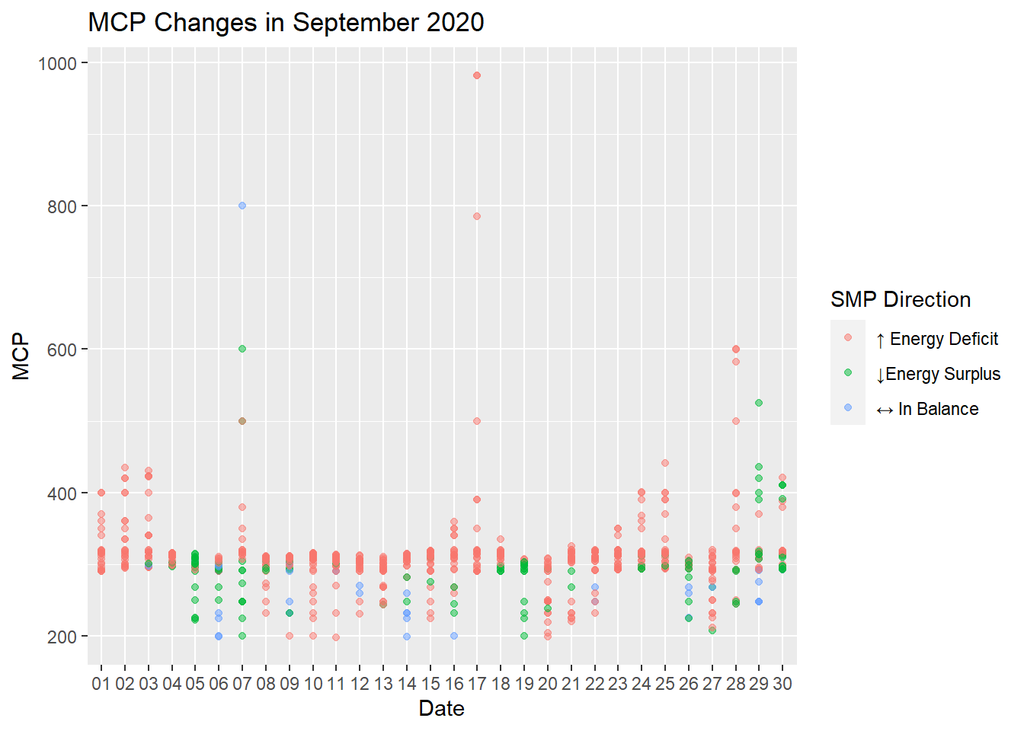

```r
df %>%
  mutate(daily = format(as.POSIXct(Date), "%d")) %>%
  ggplot(aes(daily, MCP, color = `SMP Direction`)) + geom_point(alpha = 0.5) + labs(x="Date", y="MCP", title = "MCP Changes in September 2020")
```

Each point in a day represent an hour.

According to graph,excluding outliers, the price distribution is between 200 and 450.It is observed that in general price changing is related to Energy deficit.

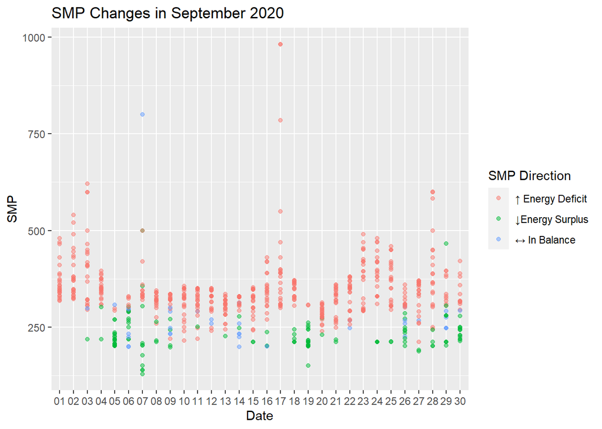

```r
df %>%
  mutate(daily = format(as.POSIXct(Date), "%d")) %>%
  ggplot(aes(daily, SMP, color = `SMP Direction`)) + geom_point(alpha = 0.5) + labs(x="Date", y="SMP", title = "SMP Changes in September 2020")
```

Each point in a day represent an hour.

Excluding outliers, the price distribution is between 200 and 500. It is observed that similar to MCP, in general price changing is related to Energy deficit.

### Ratio of SMP Direction

Based on the graphs above, the ratio of SMP Direction was analyzed. Between 720 observations, %76 of SMP is Energy Deficit, %19 of SMP is Energy Surplus and %5 of them is in balance.

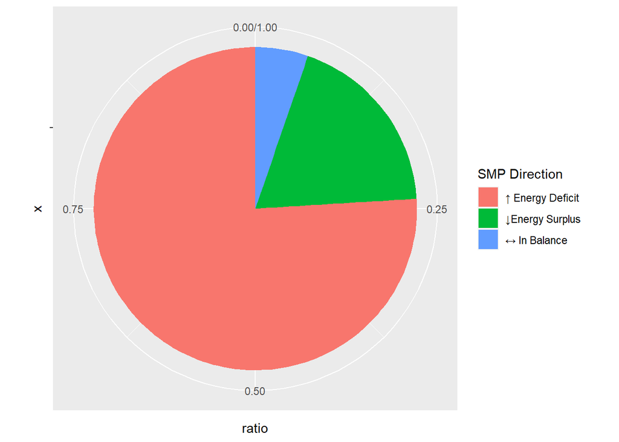

```r
df %>%
  count(`SMP Direction`) %>% mutate(total_direction = sum(n)) %>% mutate(ratio = n / total_direction) %>% ggplot(aes(x="", y = ratio, fill = `SMP Direction`)) + geom_bar(stat = "identity") + coord_polar("y")
```

### Conclusion

According to these graphs, we can conclude that many companies purchase more energy due to energy deficit and that companies have difficulty in estimating the amount of daily energy they will use. If these companies improve their prediction system, they will save on energy budget.